# Main drawing recognition analyses, validated with CLIP embeddings

Bria Long

5/8/2019, updated 10/2020, 7/2023

# Load data

## Preprocessed recognition data

```r
load(file = here::here('data/recognition_data/recognition_data_preprocessed_without_vgg.RData'))
```

## CLIP classification data

```r
load(file = here::here('data/clip_outputs/fullset/clip_long.RData'))
```

```r
clip_to_merge <- clip_long %>%
  rename(producer_age_numeric = kid_age) %>%
  mutate(session_id = paste0("cdm_", session_id)) %>%
  mutate(category = str_replace(category,' ','.')) %>%
  mutate(sketch_path = paste0(category,'_sketch_age',producer_age_numeric,'_',session_id)) %>%
  filter(category == guessed_category) %>%
  rename(clip_prob = prob) %>%
  select(sketch_path, clip_prob)
```

```r
# all_meta <- read_csv(file = here::here('data/drawings/stringent_cleaned_dataset_meta/all_object_metadata_cleaned.csv')) %>%
#   as_tibble() %>%
#   mutate(category = str_split_fixed(category,' ',2)[,2]) %>%
#   mutate(category = str_replace(category,' ','.'))  # ice cream
#
# test <- all_meta %>%
#   filter(category=='fish', age == 'age7', session_id == 'cdm_run_v21525455905420')
```

## Join datasets

```r
recog_by_clip <- kids_sketches_d %>%
  left_join(clip_to_merge, by=c('sketch_path')) %>%
  rename(log_odds = clip_prob) %>%
  filter(!is.na(log_odds))
```

Note that some sketches (271) appeared in recoggames but not in big filtered dataset Super frustrating; probably mismatches in filtering/manual selection process. Some sketches from early CDM runs (manually filtered)

```r
sketch_mismatch <- kids_sketches_d %>%
  filter(!sketch_path %in% clip_to_merge$sketch_path) %>%
  distinct(sketch_path, intended_category) %>%
  group_by(intended_category) %>%
  summarize(num_sketches = length(unique(sketch_path)))
```

```r
# fish_sketch_age7_cdm_run_v21525455905420

# what <- clip_long %>%
#   filter(category=='fish', kid_age == 7, session_id == 'run_v21525455905420')
```

```r
# assert_that(sum(is.na(recog_by_clip$log_odds))==0)
#
# assert_that(length(unique(kids_sketches_d$sketch_path))==length(unique(recog_by_clip$sketch_path)))
```

```r
# what <- recog_by_clip %>%
#   filter(is.na(clip_prob)) %>%
#   select(sketch_path) %>%
#   distinct(sketch_path) %>%
#   filter(!sketch_path %in% clip_to_merge$sketch_path)
```

## Compute distincitveness bins (used for visualizations) join classifications & recognition data

```r
num_bins=10

## compute bins for distinctiveness
sketch_by_distinctiveness <- clip_to_merge %>%
  mutate(distinct_index = ntile(clip_prob,num_bins)) %>% ## compute bins based on log odds over entire dataset
  select(sketch_path, distinct_index, clip_prob)

## join distinctiveness bins for each sketch in dataset
all_joined <- kids_sketches_d %>%
  left_join(sketch_by_distinctiveness) %>%
  filter(!is.na(clip_prob))
```

## How does distinctiveness bin vary with probilities?

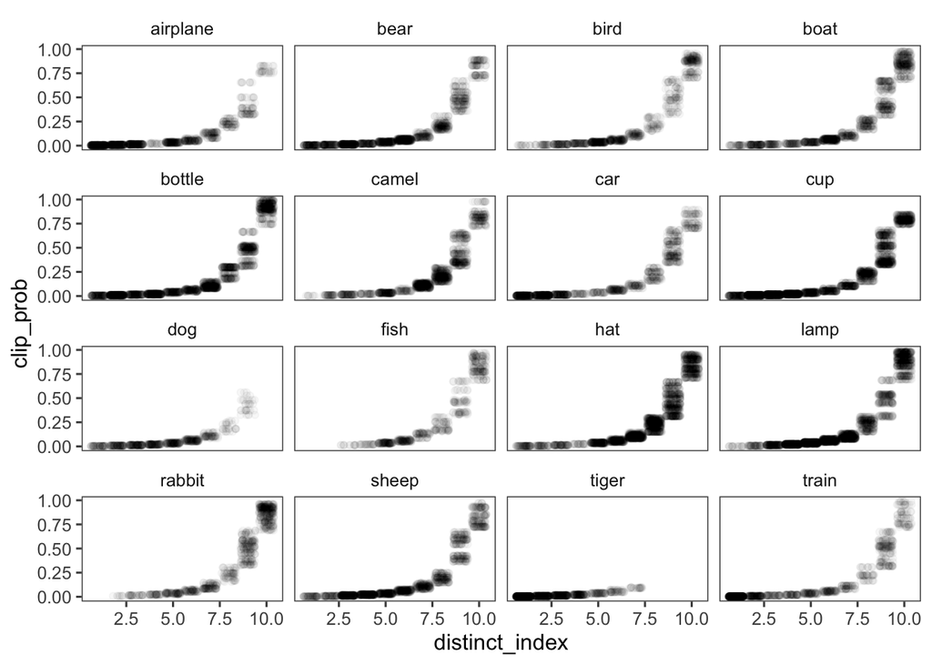

```r
ggplot(all_joined, aes(x=distinct_index, y=clip_prob)) +
  geom_jitter(alpha=.03) +
  facet_wrap(~intended_category) +
  theme_few()
```

### Plot distinctivenss by age interaction

```r
## Panel B in ms figure
distinct_by_age <- all_joined %>%
  group_by(recognizer_age_numeric, distinct_index) %>%
  multi_boot_standard(col='correct_or_not') %>%
  group_by(distinct_index) %>%
  mutate(recognizer_age_name = paste0(as.character(recognizer_age_numeric), '-year-olds'))
```

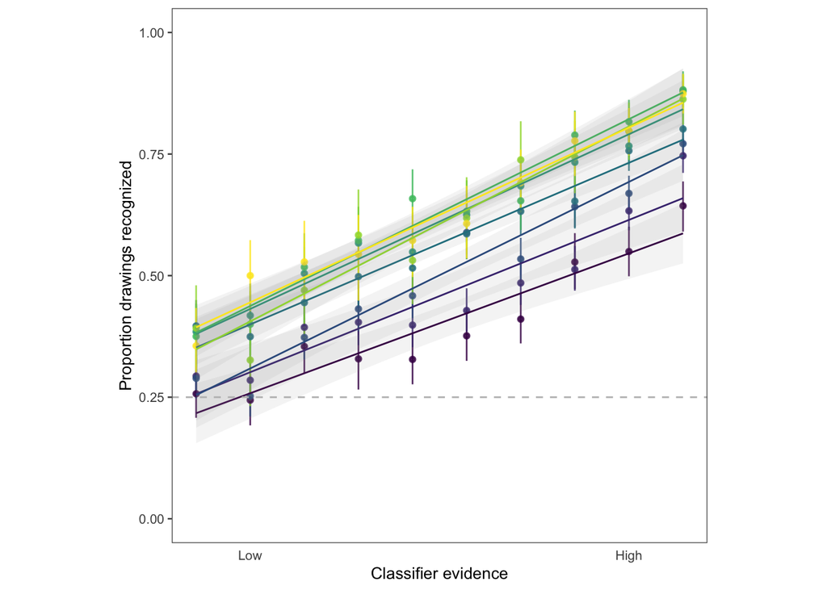

```r
 ggplot(distinct_by_age, aes(x=distinct_index, y=mean, col=as.factor(recognizer_age_numeric))) +
  geom_pointrange(aes(ymin = ci_lower, ymax = ci_upper), alpha=.8, size=.2) +
  geom_smooth(alpha=.1, span=4, size=.5, method = 'lm') +
  # facet_wrap(~recognizer_age_numeric, nrow=2) +
  theme_few(base_size = 10) +
  xlab('Classifier evidence') +
  ylab('Proportion drawings recognized') +
  theme(legend.position='none') +
  scale_color_viridis(discrete=TRUE) +
  scale_x_continuous(
    breaks=c(2,9),
    labels=c(' Low ',' High ')
        ) +
  theme(axis.ticks.x=element_blank(), aspect.ratio=1) +
  geom_hline(yintercept=.25, linetype='dashed',color='grey') +
  ylim(0,1)
```

```r
ggsave(here::here('data/figures_out/Appendix_B1_CLIP_distinctByAge.pdf'), height=3, width=3, units='in')
write_csv(distinct_by_age, file = here::here('data/figures_csvs/Appendix_B1_CLIP_distinctByAge.csv'))
```

```r
model_glmer <- glmer(correct_or_not ~ scale(clip_prob)*scale(recognizer_age_numeric) + (scale(clip_prob)|intended_category) + (1|sessionId),  data = all_joined, family='binomial')
out = summary(model_glmer)

cis_clip = confint(model_glmer, method='Wald')
```

```r
summary_model <- summary(model_glmer)

summary_table_complete <- cbind(Estimate = sprintf("%.3f",round(summary_model$coefficients[, "Estimate"],3)),
                                `Std. Error` = sprintf("%.3f",round(summary_model$coefficients[, "Std. Error"],3)),
                                `z value` = sprintf("%.3f",round(summary_model$coefficients[, "z value"],3)),
                                `Pr(>|z|)` = format.pval(summary_model$coefficients[, "Pr(>|z|)"],eps=0.0001,scientific = FALSE, digits=2),
                                 `2.5 % CI` = sprintf("%.3f",round(cis_clip[5:8, 1],3)),
                                `97.5 % CI` = sprintf("%.3f",round(cis_clip[5:8, 2],3)))

rownames(summary_table_complete) = c('Intercept','Classifier evidence', 'Recognizer age','Classifier evidence*Recognizer Age')
```

```r
xtable::xtable(summary_table_complete, digits=3, caption = "Model coefficients of a generalized linear mixed-effects model predicting binary visual recognition performance for each drawing as a function of recognizer age and CLIP classifier evidence in each drawing that was recognized by children. All predictors were z-scored prior to analysis such that coefficients are standardized and comparable. All significance tests are Wald significance tests based on the coefficient values; these tests are two-tailed. No adjustments were made for multiple comparisons. See \textit{Methods} for model details on model specifications.")
```

```
## % latex table generated in R 4.3.1 by xtable 1.8-4 package
## % Thu Jan 18 14:53:28 2024
## \begin{table}[ht]
## \centering
## \begin{tabular}{rllllll}
##   \hline
##  & Estimate & Std. Error & z value & Pr($>$$|$z$|$) & 2.5 \% CI & 97.5 \% CI \\
##   \hline
## Intercept & 0.397 & 0.183 & 2.167 & 0.03 & 0.038 & 0.757 \\
##   Classifier evidence & 0.987 & 0.215 & 4.590 & $<$0.0001 & 0.566 & 1.409 \\
##   Recognizer age & 0.367 & 0.021 & 17.644 & $<$0.0001 & 0.326 & 0.408 \\
##   Classifier evidence*Recognizer Age & 0.091 & 0.018 & 5.079 & $<$0.0001 & 0.056 & 0.126 \\
##    \hline
## \end{tabular}
## \caption{Model coefficients of a generalized linear mixed-effects model predicting binary visual recognition performance for each drawing as a function of recognizer age and CLIP classifier evidence in each drawing that was recognized by children. All predictors were z-scored prior to analysis su…
## \end{table}
```

**R version 4.3.1 (2023-06-16)**

**Platform:** x86_64-apple-darwin20 (64-bit)

**locale:** en_US.UTF-8||en_US.UTF-8||en_US.UTF-8||C||en_US.UTF-8||en_US.UTF-8

**attached base packages:** *stats*, *graphics*, *grDevices*, *utils*, *datasets*, *methods* and *base*

**other attached packages:** *pander(v.0.6.5)*, *lmerTest(v.3.1-3)*, *lme4(v.1.1-34)*, *Matrix(v.1.6-1)*, *ggthemes(v.4.2.4)*, *viridis(v.0.6.4)*, *viridisLite(v.0.4.2)*, *langcog(v.0.1.9001)*, *assertthat(v.0.2.1)*, *knitr(v.1.43)*, *lubridate(v.1.9.2)*, *forcats(v.1.0.0)*, *stringr(v.1.5.0)*, *dplyr(v.1.1.2)*, *purrr(v.1.0.2)*, *readr(v.2.1.4)*, *tidyr(v.1.3.0)*, *tibble(v.3.2.1)*, *ggplot2(v.3.4.3)* and *tidyverse(v.2.0.0)*

**loaded via a namespace (and not attached):** *tidyselect(v.1.2.0)*, *farver(v.2.1.1)*, *fastmap(v.1.1.1)*, *lazyeval(v.0.2.2)*, *digest(v.0.6.33)*, *rpart(v.4.1.19)*, *timechange(v.0.2.0)*, *lifecycle(v.1.0.3)*, *cluster(v.2.1.4)*, *magrittr(v.2.0.3)*, *compiler(v.4.3.1)*, *rlang(v.1.1.1)*, *Hmisc(v.5.1-1)*, *sass(v.0.4.7)*, *tools(v.4.3.1)*, *utf8(v.1.2.3)*, *yaml(v.2.3.7)*, *data.table(v.1.14.8)*, *labeling(v.0.4.2)*, *htmlwidgets(v.1.6.2)*, *bit(v.4.0.5)*, *here(v.1.0.1)*, *withr(v.2.5.0)*, *foreign(v.0.8-84)*, *numDeriv(v.2016.8-1.1)*, *nnet(v.7.3-19)*, *grid(v.4.3.1)*, *fansi(v.1.0.4)*, *xtable(v.1.8-4)*, *colorspace(v.2.1-0)*, *scales(v.1.2.1)*, *MASS(v.7.3-60)*, *cli(v.3.6.1)*, *crayon(v.1.5.2)*, *rmarkdown(v.2.24)*, *ragg(v.1.2.5)*, *generics(v.0.1.3)*, *rstudioapi(v.0.15.0)*, *tzdb(v.0.4.0)*, *minqa(v.1.2.5)*, *cachem(v.1.0.8)*, *splines(v.4.3.1)*, *parallel(v.4.3.1)*, *base64enc(v.0.1-3)*, *vctrs(v.0.6.3)*, *boot(v.1.3-28.1)*, *jsonlite(v.1.8.7)*, *hms(v.1.1.3)*, *bit64(v.4.0.5)*, *Formula(v.1.2-5)*, *htmlTable(v.2.4.1)*, *systemfonts(v.1.0.4)*, *jquerylib(v.0.1.4)*, *glue(v.1.6.2)*, *nloptr(v.2.0.3)*, *stringi(v.1.7.12)*, *gtable(v.0.3.4)*, *munsell(v.0.5.0)*, *pillar(v.1.9.0)*, *htmltools(v.0.5.6)*, *R6(v.2.5.1)*, *textshaping(v.0.3.6)*, *rprojroot(v.2.0.3)*, *vroom(v.1.6.3)*, *evaluate(v.0.21)*, *lattice(v.0.21-8)*, *highr(v.0.10)*, *backports(v.1.4.1)*, *bslib(v.0.5.1)*, *Rcpp(v.1.0.11)*, *gridExtra(v.2.3)*, *nlme(v.3.1-162)*, *checkmate(v.2.2.0)*, *mgcv(v.1.8-42)*, *xfun(v.0.40)* and *pkgconfig(v.2.0.3)*